# Calculation of holding income

MtM ABM description

Author

David O’Sullivan

Published

July 2, 2024

Modified

October 17, 2025

## Baseline income equation for holdings

The baseline profit $Z$ of each hectare of a holding is given by

$$Z=Y-X$$

where $Y$ is gross income, and $X$ is total costs. These are in turn given by

$$\begin{array}{rcl}
Y &=& pq \\
X &=& x+te
\end{array}$$

where

- $p$ is the price obtained per unit,
- $q$ is the quantity produced per hectare,
- $x$ is the cost per hectare to operate,
- $e_i$ are various environmental metrics per hectare, most obviously greenhouse gas emissions, and
- $t_i$ are any environmental taxes associated with each environmental metric.

Each of these parameters may depend on the farm type $F$ and the land use capability (LUC), $L$, such that the full calculation of profit for each hectare of a holding is
$$Z_{FL} = p_Fq_{FL} - x_{FL} - \sum_i t_ie_{i,FL}$$
and total holding profit is obtaining by summing this quantity across all hectares of the holding. Overall profit of a farm is determined by summation across all its constituent holdings. Note that while currently all cells in a holding have the same LUC this is not a requirement and the calculation will work equally well if LUC were to vary across a holding.

### Parameter values

The parameter values are stored in a number of CSV files which are read in by the model at start up from the `.data/market/<scenario>` folder specified.

#### Prices and environmental taxes

$p_F$ is found in the `prices.csv` file:

```r
prices <- read.csv(str_glue("{base_dir}/prices.csv"),
                   header = T, row.names = 1) |>
  slice(1:2) # only rows 1 & 2 relevant
prices |>
  kable() |>
  kable_styling("striped", full_width = F)
```

|  | SNB | Dairy | Forest | Crop |
| --- | --- | --- | --- | --- |
| price | 5 | 7.5 | 157 | 0.5 |

```r
print(read.csv(str_glue("{base_dir}/environmental-metrics.csv"), header = T, row.names = 1))
```

```
              limit price
ghg_emissions    10    10
nitrates         11     0
sediment         10     0
phosphates        1     0
e_coli            4     0
```

In the remainder of this page we assume only greenhouse gases are taxed and use the simplified form $te$ for the environmental tax burden in preference to the more complete $\sum_i t_ie_{i,FL}$ shown above.

#### Yields

```r
yields <- read.csv(str_glue("{base_dir}/yields.csv"), header = T)
yields |>
  mutate(across(3:6, ~ round(., 1))) |>
  kable() |>
  kable_styling("striped", full_width = F) |>
  scroll_box(height = "250px")
```

| mean_or_sd | LUC | SNB | Dairy | Forest | Crop |
| --- | --- | --- | --- | --- | --- |
| Mean | 1 | 768.5 | 1503.0 | 30.0 | 9667.0 |
| Mean | 2 | 581.2 | 1283.0 | 29.0 | 9183.6 |
| Mean | 3 | 372.4 | 1174.3 | 28.0 | 8724.5 |
| Mean | 4 | 332.2 | 923.4 | 27.0 | 8288.2 |
| Mean | 5 | 259.5 | 877.7 | 26.0 | 7873.8 |
| Mean | 6 | 207.4 | 845.8 | 25.0 | 7480.1 |
| Mean | 7 | 193.2 | 700.0 | 24.0 | 7106.1 |
| Mean | 8 | 49.9 | 661.0 | 23.0 | 6750.8 |
| SD | 1 | 153.7 | 300.6 | 6.0 | 1933.4 |
| SD | 2 | 116.2 | 256.6 | 5.8 | 1836.7 |
| SD | 3 | 74.5 | 234.9 | 5.6 | 1744.9 |
| SD | 4 | 66.4 | 184.7 | 5.4 | 1657.6 |
| SD | 5 | 51.9 | 175.5 | 5.2 | 1574.8 |
| SD | 6 | 41.5 | 169.2 | 5.0 | 1496.0 |
| SD | 7 | 38.6 | 140.0 | 4.8 | 1421.2 |
| SD | 8 | 10.0 | 132.2 | 4.6 | 1350.2 |

#### Costs

```r
costs <- read.csv(str_glue("{base_dir}/costs.csv"), header = TRUE)
costs |>
  mutate(across(3:6, ~ round(., 1))) |>
  kable() |>
  kable_styling("striped", full_width = F) |>
  scroll_box(height = "250px")
```

| mean_or_sd | LUC | SNB | Dairy | Forest | Crop |
| --- | --- | --- | --- | --- | --- |
| Mean | 1 | 3500 | 9500 | 4000 | 3000 |
| SD | 1 | 700 | 1900 | 800 | 600 |
| Mean | 2 | 2650 | 8050 | 4000 | 2850 |
| SD | 2 | 530 | 1610 | 800 | 570 |
| Mean | 3 | 1625 | 7350 | 3850 | 2675 |
| SD | 3 | 325 | 1470 | 770 | 535 |
| Mean | 4 | 1450 | 5500 | 3700 | 2500 |
| SD | 4 | 290 | 1100 | 740 | 500 |
| Mean | 5 | 1110 | 5200 | 3550 | 2400 |
| SD | 5 | 222 | 1040 | 710 | 480 |
| Mean | 6 | 875 | 5000 | 3500 | 2200 |
| SD | 6 | 175 | 1000 | 700 | 440 |
| Mean | 7 | 810 | 4000 | 3375 | 2100 |
| SD | 7 | 162 | 800 | 675 | 420 |
| Mean | 8 | 125 | 4000 | 3250 | 2000 |
| SD | 8 | 25 | 800 | 650 | 400 |

#### Emissions

Emissions per ha. by farm type and land use capability, $e_{FL}$, are in the `ghg_emissions.csv` file:

```r
emissions <- read.csv(str_glue("{base_dir}/ghg_emissions.csv"), header = TRUE)
emissions |>
  mutate(across(3:6, ~ round(., 1))) |>
  kable() |>
  kable_styling("striped", full_width = F) |>
  scroll_box(height = "250px")
```

| mean_or_sd | LUC | SNB | Dairy | Forest | Crop |
| --- | --- | --- | --- | --- | --- |
| Mean | 1 | 4.0 | 11.0 | -15.0 | 1.2 |
| SD | 1 | 1.2 | 3.3 | 4.5 | 0.4 |
| Mean | 2 | 3.8 | 10.5 | -14.2 | 1.1 |
| SD | 2 | 1.1 | 3.1 | 4.3 | 0.3 |
| Mean | 3 | 3.5 | 10.0 | -13.5 | 1.1 |
| SD | 3 | 1.0 | 3.0 | 4.1 | 0.3 |
| Mean | 4 | 3.2 | 9.5 | -12.9 | 1.0 |
| SD | 4 | 1.0 | 2.9 | 3.9 | 0.3 |
| Mean | 5 | 3.0 | 9.0 | -12.2 | 1.0 |
| SD | 5 | 0.9 | 2.7 | 3.7 | 0.3 |
| Mean | 6 | 2.8 | 8.5 | -11.6 | 0.9 |
| SD | 6 | 0.8 | 2.5 | 3.5 | 0.3 |
| Mean | 7 | 2.5 | 8.0 | -11.0 | 0.9 |
| SD | 7 | 0.8 | 2.4 | 3.3 | 0.3 |
| Mean | 8 | 2.2 | 7.5 | -10.5 | 0.8 |
| SD | 8 | 0.7 | 2.2 | 3.1 | 0.3 |

Note that all of yields, base costs, and emissions are stored as a mean and a standard deviation, and that each holding will see these numbers vary every model time period by drawing from a normal distribution.

We can use these data to show the profit, gross income, and total costs for each farm type across different land use capability classes. We’ll throw away the standard deviations for simplicity and consider only mean outcomes.

```r
prices <- prices |>
  t() |>
  as.data.frame() |>
  tibble::rownames_to_column("farm_type") |>
  mutate(carbon_tax = 10)

yields <- yields |>
  mutate(across(3:6, ~ round(., 1))) |>
  filter(mean_or_sd == "Mean") |>
  select(-mean_or_sd) |>
  pivot_longer(-1) |>
  rename(farm_type = name, yield = value)

costs <- costs |>
  mutate(across(3:6, ~ round(., 1))) |>
  filter(mean_or_sd == "Mean") |>
  select(-mean_or_sd) |>
  pivot_longer(-1) |>
  rename(farm_type = name, cost = value)

emissions <- emissions |>
  mutate(across(3:6, ~ round(., 1))) |>
  filter(mean_or_sd == "Mean") |>
  select(-mean_or_sd) |>
  pivot_longer(-1) |>
  rename(farm_type = name, emissions = value)

combined_data <- prices |>
  left_join(yields) |>
  left_join(costs) |>
  left_join(emissions) |>
  mutate(gross_income = price * yield, # LUC = as.factor(LUC),
         total_costs = cost + carbon_tax * emissions, base_costs = cost,
         profit = gross_income - total_costs) |>
  select(farm_type, LUC, profit, price, yield, gross_income, base_costs,
         emissions, carbon_tax, total_costs) |>
  rename(Profit = profit, `Gross income` = gross_income, `Total costs` = total_costs)

combined_data |>
  kable() |>
  kable_styling("striped", full_width = F) |>
  scroll_box(height = "250px")
```

| farm_type | LUC | Profit | price | yield | Gross income | base_costs | emissions | carbon_tax | Total costs |
| --- | --- | --- | --- | --- | --- | --- | --- | --- | --- |
| SNB | 1 | 302.50 | 5.0 | 768.5 | 3842.50 | 3500 | 4.0 | 10 | 3540 |
| SNB | 2 | 218.00 | 5.0 | 581.2 | 2906.00 | 2650 | 3.8 | 10 | 2688 |
| SNB | 3 | 202.00 | 5.0 | 372.4 | 1862.00 | 1625 | 3.5 | 10 | 1660 |
| SNB | 4 | 179.00 | 5.0 | 332.2 | 1661.00 | 1450 | 3.2 | 10 | 1482 |
| SNB | 5 | 157.50 | 5.0 | 259.5 | 1297.50 | 1110 | 3.0 | 10 | 1140 |
| SNB | 6 | 134.00 | 5.0 | 207.4 | 1037.00 | 875 | 2.8 | 10 | 903 |
| SNB | 7 | 131.00 | 5.0 | 193.2 | 966.00 | 810 | 2.5 | 10 | 835 |
| SNB | 8 | 102.50 | 5.0 | 49.9 | 249.50 | 125 | 2.2 | 10 | 147 |
| Dairy | 1 | 1662.50 | 7.5 | 1503.0 | 11272.50 | 9500 | 11.0 | 10 | 9610 |
| Dairy | 2 | 1467.50 | 7.5 | 1283.0 | 9622.50 | 8050 | 10.5 | 10 | 8155 |
| Dairy | 3 | 1357.25 | 7.5 | 1174.3 | 8807.25 | 7350 | 10.0 | 10 | 7450 |
| Dairy | 4 | 1330.50 | 7.5 | 923.4 | 6925.50 | 5500 | 9.5 | 10 | 5595 |
| Dairy | 5 | 1292.75 | 7.5 | 877.7 | 6582.75 | 5200 | 9.0 | 10 | 5290 |
| Dairy | 6 | 1258.50 | 7.5 | 845.8 | 6343.50 | 5000 | 8.5 | 10 | 5085 |
| Dairy | 7 | 1170.00 | 7.5 | 700.0 | 5250.00 | 4000 | 8.0 | 10 | 4080 |
| Dairy | 8 | 882.50 | 7.5 | 661.0 | 4957.50 | 4000 | 7.5 | 10 | 4075 |
| Forest | 1 | 860.00 | 157.0 | 30.0 | 4710.00 | 4000 | -15.0 | 10 | 3850 |
| Forest | 2 | 695.00 | 157.0 | 29.0 | 4553.00 | 4000 | -14.2 | 10 | 3858 |
| Forest | 3 | 681.00 | 157.0 | 28.0 | 4396.00 | 3850 | -13.5 | 10 | 3715 |
| Forest | 4 | 668.00 | 157.0 | 27.0 | 4239.00 | 3700 | -12.9 | 10 | 3571 |
| Forest | 5 | 654.00 | 157.0 | 26.0 | 4082.00 | 3550 | -12.2 | 10 | 3428 |
| Forest | 6 | 541.00 | 157.0 | 25.0 | 3925.00 | 3500 | -11.6 | 10 | 3384 |
| Forest | 7 | 503.00 | 157.0 | 24.0 | 3768.00 | 3375 | -11.0 | 10 | 3265 |
| Forest | 8 | 466.00 | 157.0 | 23.0 | 3611.00 | 3250 | -10.5 | 10 | 3145 |
| Crop | 1 | 1821.50 | 0.5 | 9667.0 | 4833.50 | 3000 | 1.2 | 10 | 3012 |
| Crop | 2 | 1730.80 | 0.5 | 9183.6 | 4591.80 | 2850 | 1.1 | 10 | 2861 |
| Crop | 3 | 1676.25 | 0.5 | 8724.5 | 4362.25 | 2675 | 1.1 | 10 | 2686 |
| Crop | 4 | 1634.10 | 0.5 | 8288.2 | 4144.10 | 2500 | 1.0 | 10 | 2510 |
| Crop | 5 | 1526.90 | 0.5 | 7873.8 | 3936.90 | 2400 | 1.0 | 10 | 2410 |
| Crop | 6 | 1531.05 | 0.5 | 7480.1 | 3740.05 | 2200 | 0.9 | 10 | 2209 |
| Crop | 7 | 1444.05 | 0.5 | 7106.1 | 3553.05 | 2100 | 0.9 | 10 | 2109 |
| Crop | 8 | 1367.40 | 0.5 | 6750.8 | 3375.40 | 2000 | 0.8 | 10 | 2008 |

### Or visually…

Below are shown the income, costs, and net revenue per hectare for each farm type across the eight land use capability classes. These are crude estimates dating back to the ARLUNZ model[^1] and will be updated in due course. Even so it is expected that the relative profitability of the different broad land use classes will remain similar.

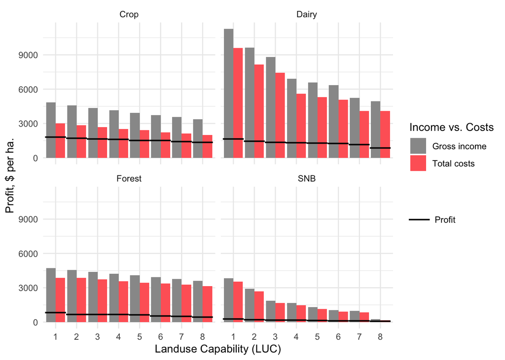

```r
plot_data <- combined_data |>
  pivot_longer(cols = c("Gross income", "Profit", "Total costs"))

ggplot(plot_data |> filter(name %in% c("Gross income", "Total costs"))) +
  geom_col(aes(x = as.factor(LUC), y = value, group = name, fill = name),
           position = "dodge") +
  scale_fill_manual(values = c("#999999", "#ff6666"), name = "Income vs. Costs") +
  geom_point(data = plot_data |> filter(name == "Profit"),
            aes(x = LUC, y = value, shape = name), size = 7) +
  scale_shape_manual(values = "\u2014", name = "") + # \u2014 is an em-dash
  xlab("Landuse Capability (LUC)") +
  ylab("Profit, $ per ha.") +
  facet_wrap(~ farm_type) +
  theme_minimal()
```

**Update History**

| Date | Changes |
| --- | --- |
| 2024-07-02 | Initial post. |
| 2024-07-03 | Added bar chart of farm income/costs estimates. |
| 2024-07-04 | Added detail on calculation of relative change noting that profit can’t be handled this way because it is $\pm$ and relative change is meaningless for such variables. |
| 2024-07-05 | Corrected relative change from a percentage to a proportion. |
| 2024-07-28 | Correction in equation summarising full calculation of profit. Added note to consider the nudge calculation’s possible bias favouring changes *after* bad years. |
| 2025-02-19 | Split out from previous ‘core loop’ document. |
| 2025-10-17 | Corrected code to cope with new formatting of various datasets. |

## Footnotes

[^1]: See: Morgan FJ and AJ Daigneault. 2015. [Estimating Impacts of Climate Change Policy on Land Use: An Agent-Based Modelling Approach](https://dx.doi.org/10.1371/journal.pone.0127317). *PLOS ONE* **10**(5): e0127317.